# Styles and Climate Analysis (Proof-of-concept)

Note: This POC is to showcase the type of text analysis that we could do to support our studies. I genrally relied on this framework here (https://www.tidytextmining.com/) for the analysis

Before I started my analysis, I used textcat package to identify the text rows that’re in English.

Here is an example of the 1st 2 rows in the dataset (only Strengths used here. I left out weakneess in the analysis).

```
##           GroupID           PerID        UserName
## 8 GROW00000182823 PERW00002545425 MQF552ZH
## 9 GROW00000182459 PERW00002555825 Q3G2L5J5
##                                                                                                                                                                                                                                                                                                          …
## 8 She is a very positive and energizing person.  She likes getting to know people better and communicating with them with the tone each will understand better.  She likes innovative thinking rather than following the standard.  She's a hard worker, she feels better when she produces results that …
## 9                                                                                                                                                                                                                                                                                                        …
```

Then I tokenize the dataset through unigrams i.e 1 word / term

Next I identify stop words in the data frame by merging in a taxonomy from tidytext package. And removed them thereafter.

I then use count function to find the most common words under the ‘Strengths Column’.

We could see that the most common words are ‘team’, ‘people’, ‘leadership’, ‘positive’ - suggesting that people tend to have these attributes as their strenghts

```
## # A tibble: 44,807 x 2
##          word     n
##         <chr> <int>
##  1       team 92549
##  2     people 29500
##  3 leadership 23050
##  4     leader 22494
##  5     strong 18185
##  6       time 17211
##  7   business 16274
##  8     skills 13301
##  9   positive 13030
## 10    ability 12931
## # ... with 44,797 more rows
```

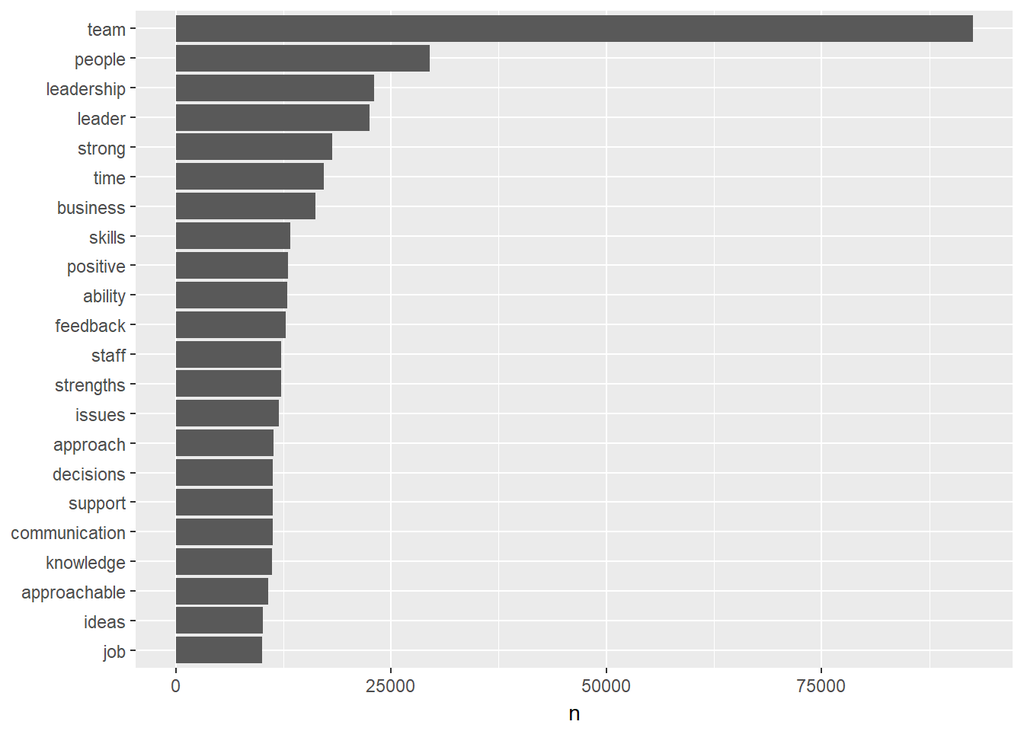

## Sentiment analysis

1 of the common toolkits in text analysis is Sentiment Analysis. Using an existing sentiment taxonomy, I’m able to tag words as positive or negative.

```
## # A tibble: 3,024 x 3
##          word sentiment     n
##         <chr>     <chr> <int>
##  1     strong  positive 18185
##  2   positive  positive 13030
##  3     issues  negative 11993
##  4    support  positive 11291
##  5 supportive  positive  9396
##  6      leads  positive  8078
##  7      trust  positive  7773
##  8     honest  positive  6970
##  9       lead  positive  6482
## 10  excellent  positive  6165
## # ... with 3,014 more rows
```

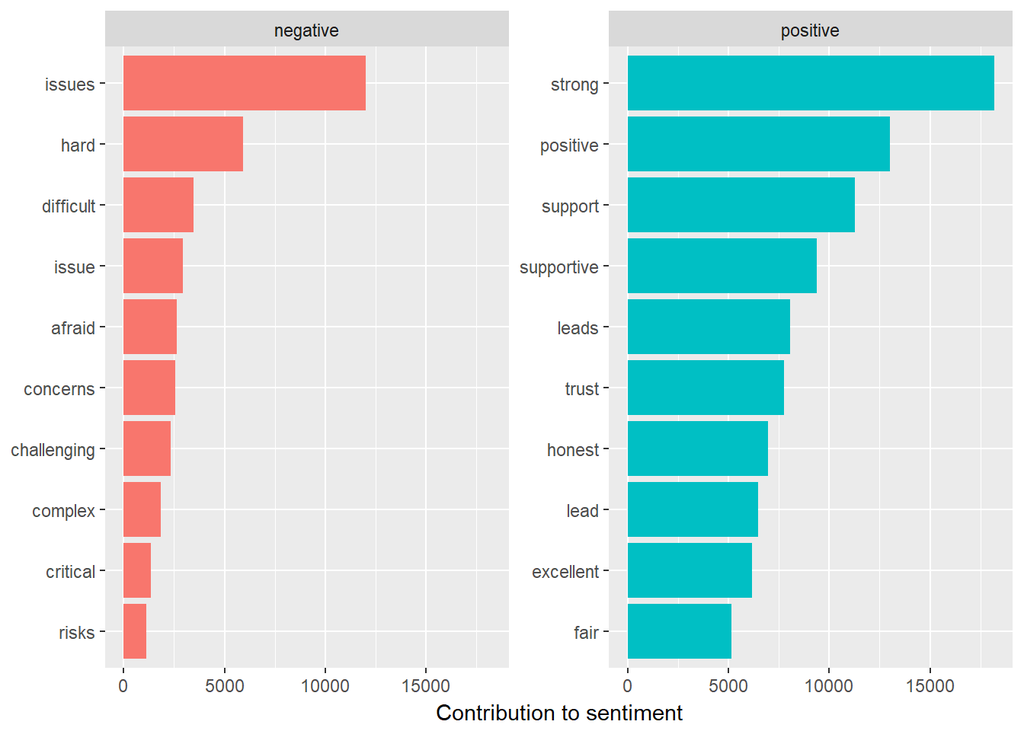

##Word-cloud

A common way to visualize text-analysis is through word clouds. In this section, I plot the word cloud - with the larger words depicting the more common terms in the text.

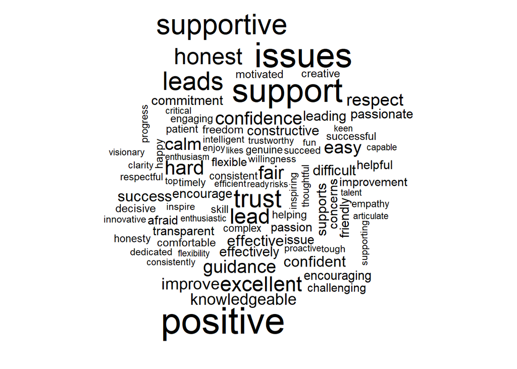

## TF-IDF (KIV this section first)

## Topic-Modelling

I then fit a document term matrix into the Latent Dirichlet Allocation (LDA) unsupervised machine-learning framework. ‘Unsupervised Machine Learning’ is a fancy way of saying Exploratory Thematic Analysis.

As a POC, I set 2 as the number of latent topics that are able to represent the dataset. There are diagnostics to determine the optimal number. I will explore that in future iterations.

```
## A LDA_VEM topic model with 2 topics.
```

## Word-topic probabilities

LDA allows us to extract per-topic-per-word probabilities (Beta) from the model.

The model assigned probabilities to each term of being generated from either of the 2 topics.

As you would notice, many of the terms below are not formatted properly (e.g. punctuations and numbers ought to be removed; only keep the root words through stemming). I will do so in further iterations.

```
## # A tibble: 89,606 x 3
##    topic       term         beta
##    <int>      <chr>        <dbl>
##  1     1        ___ 1.284070e-06
##  2     2        ___ 2.895536e-07
##  3     1       ____ 2.986492e-07
##  4     2       ____ 4.899843e-07
##  5     1     ______ 4.271346e-07
##  6     2     ______ 3.608173e-07
##  7     1  _decision 4.579167e-07
##  8     2  _decision 3.298719e-07
##  9     1 _excessive 2.415645e-07
## 10     2 _excessive 5.473718e-07
## # ... with 89,596 more rows
```

Next, I find the top 10 terms that best represents each topic. In the graphs below, it doesn’t show any clear distinction - with a couple of terms falling in both baskets.

Model could be further tuned to obtain better distinctions (e.g. increasing number of topics, further data-cleaning, using n-grams i.e. n words per term instead of 1 word per term now)

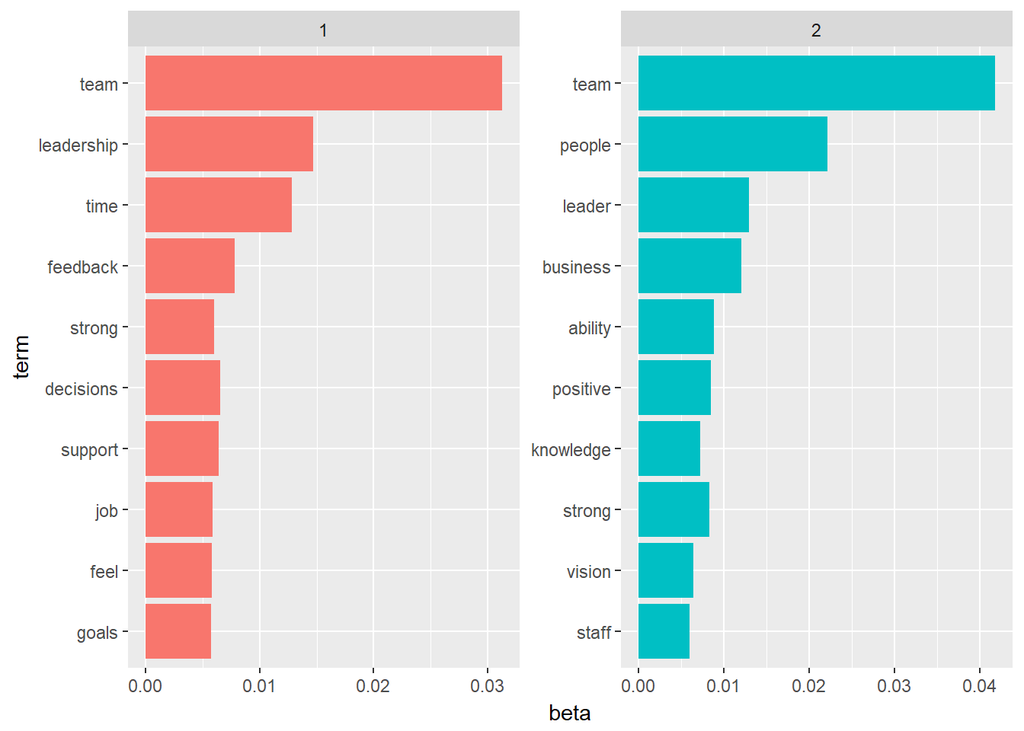

## Per-document classification

Through LDA, we are also able to assign a topic to each document - in our case, a topic to each comment.

```
## # A tibble: 250,814 x 3
##           document topic     gamma
##              <chr> <int>     <dbl>
##  1 2222276Z            1 0.4962823
##  2 2222276Z            2 0.5037177
##  3 22224ZTD            1 0.4968643
##  4 22224ZTD            2 0.5031357
##  5 2223455G            1 0.4933656
##  6 2223455G            2 0.5066344
##  7 222365KZ            1 0.5128938
##  8 222365KZ            2 0.4871062
##  9 2223H4KC            1 0.5065779
## 10 2223H4KC            2 0.4934221
## # ... with 250,804 more rows
```

### Potential applications

With LDA, we’re able to find out the topics that are commonly associated with high performers. And if there’re demographic and job variables, we can explore these tendencies by gender, occupations, industries, etc.